# MaRe - Resultados preliminares

Autores

João V. F. Cavalcante

Rodrigo Dalmolin

# Descrição das amostras

| Amostra | Local |
| --- | --- |
| PB4 | EstuárioBarradeMamanguape |
| PB7 | EstuárioBarradeMamanguape |
| PB11 | EstuárioCabedelo |
| PB9 | EstuárioCabedelo |
| PB3 | RestingaBarradeMamanguape |
| PB1 | RestingaBarradeMamanguapeAçude |
| PB12 | RestingaCabedeloRio |

# Metodologia

A análise foi realizada com o pipeline nf-core/mag v4.0.0 (Krakau et al. 2022), orquestrado pelo gerenciador de fluxos de trabalho Nextflow e utilizando o perfil Singularity. O script utilizado para a análise pode ser encontrado [aqui](https://github.com/dalmolingroup/mare/blob/main/scripts/run_mag.sh).

# Controle de Qualidade

## Contagens de reads

Cada amostra possui por volta de 60M a 100M de *reads* não-duplicadas.

Abaixo, valores obtidos com o software FastQC (Andrews 2010).

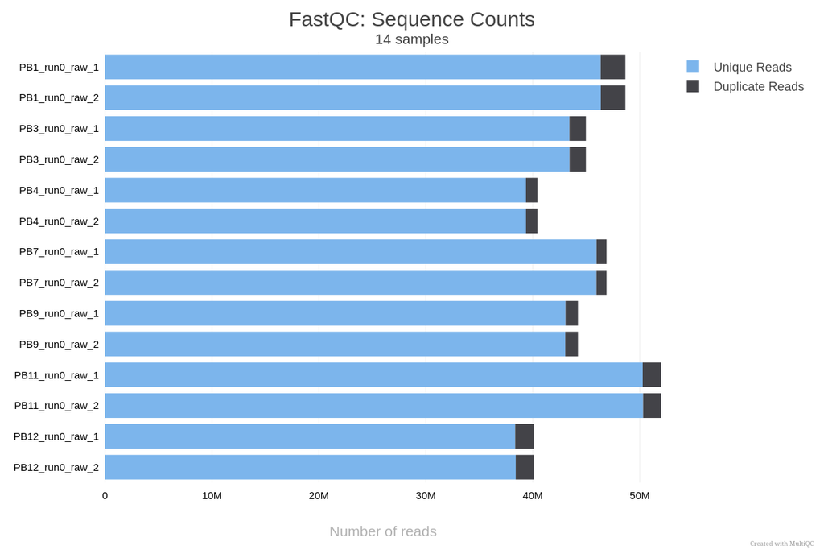

Contagens do número absoluto de *reads* duplicadas e não duplicadas em cada amostra

[figure not shown]

Porcentagem de *reads* duplicadas e não duplicadas em cada amostra

## Filtragem de *reads*

Utilizando fastp (Chen et al. 2018), por volta de 99% das *reads* foram mantidas em todas as amostras - uma retenção alta e adequada pra fazer uma caracterização profunda do microbioma.

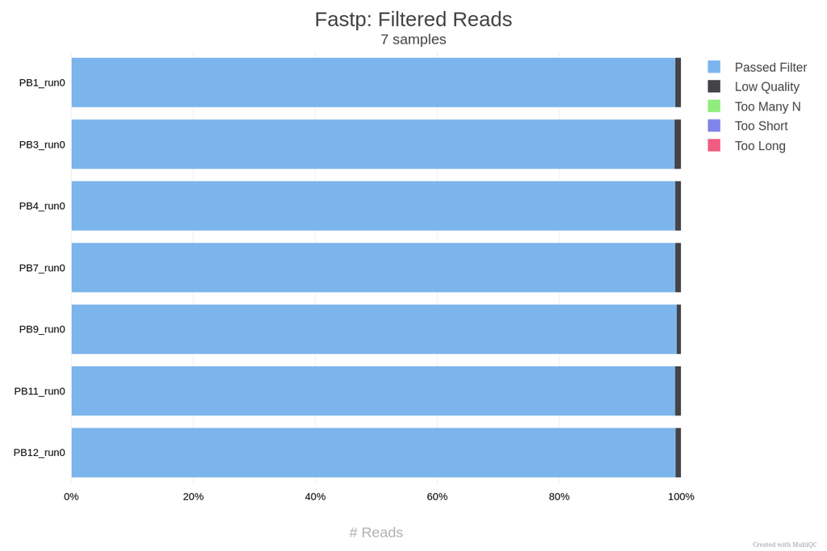

Porcetagem de *reads* retidas em cada amostra

## Classificação taxonômica

Utilizando o banco de dados *standardpluspf* (Bacteria, Archaea, Protozoa e Fungi) do Kraken2 (Wood, Lu, e Langmead 2019) para observar a classificação taxonômica das leituras, observamos que por volta de 50-60% das *reads* resultaram em nenhuma classificação, o que é esperado dado a profundidade do sequenciamento.

[figure not shown]

Resultado da classificação taxonômica com Kraken2, a nível de reino

[figure not shown]

Resultado da classificação taxonômica com Kraken2, a nível de filo

[figure not shown]

Resultado da classificação taxonômica com Kraken2, a nível de família

# Montagem

Após montagem com o MEGAHIT (Li et al. 2015), observamos que a maioria dos *contigs* possuem um comprimento de até 1000 pares de base.

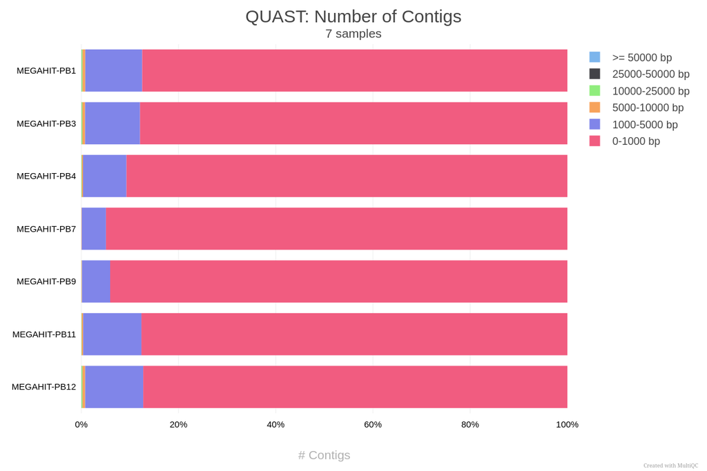

Porcentagem de *contigs* de cada comprimento nas montagens de cada amostra

Valores de N50 e N75 mostram resultados bons.

[figure not shown]

# Binning

Após uma abordagem híbrida de binning utilizando os softwares MaxBin (Wu, Simmons, e Singer 2016), CONCOCT (Alneberg et al. 2014) e MetaBAT2 (Kang et al. 2019), seguida de refinamento com o DASTool (Sieber et al. 2018), pudemos obter inicialmente **1,549 *bins*, que foram refinados para 137 *metagenome-assembled genomes* (MAGs)**.

Após o refinamento, notamos melhorias quanto ao comprimento dos *contigs* quando comparados às montagens brutas.

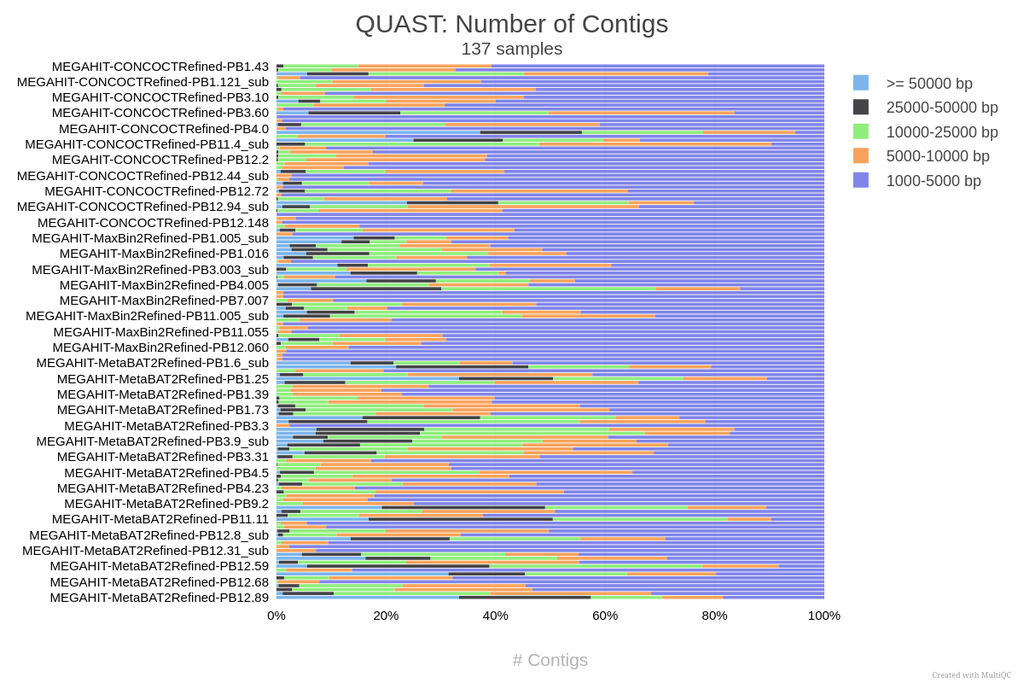

Porcentagem de *contigs* de cada comprimento nas MAGs obtidas

## Predição de domínio

Realizamos um passo de predição de sequências eucarióticas, procarióticas e de archaea com o software Tiara (Karlicki, Antonowicz, e Karnkowska 2021), mostrando que quase todas as MAGs obtidas são procarióticas.

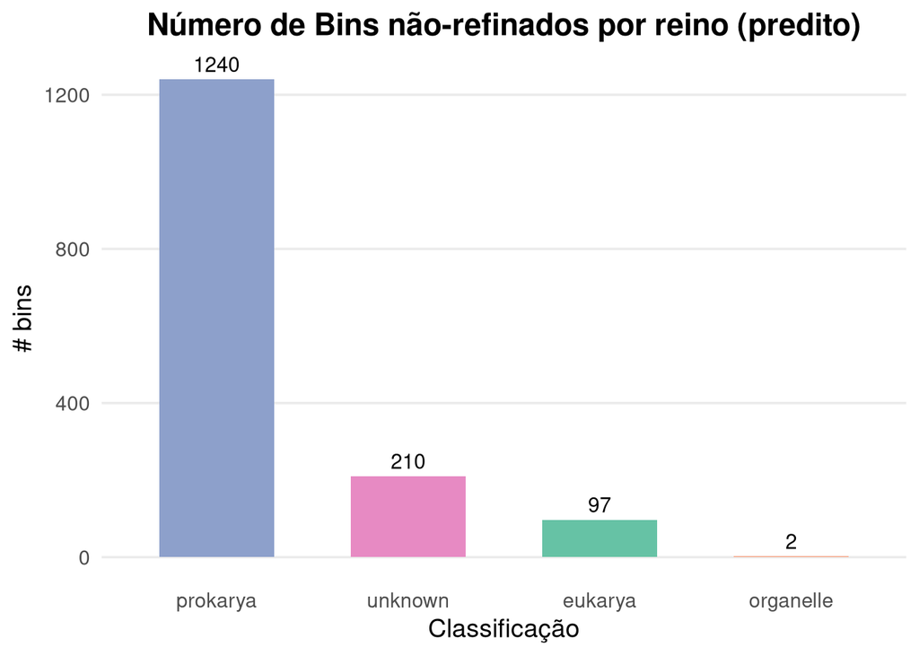

Considerando apenas bins pós-refinamento, a predominância de *prokarya* permanece.

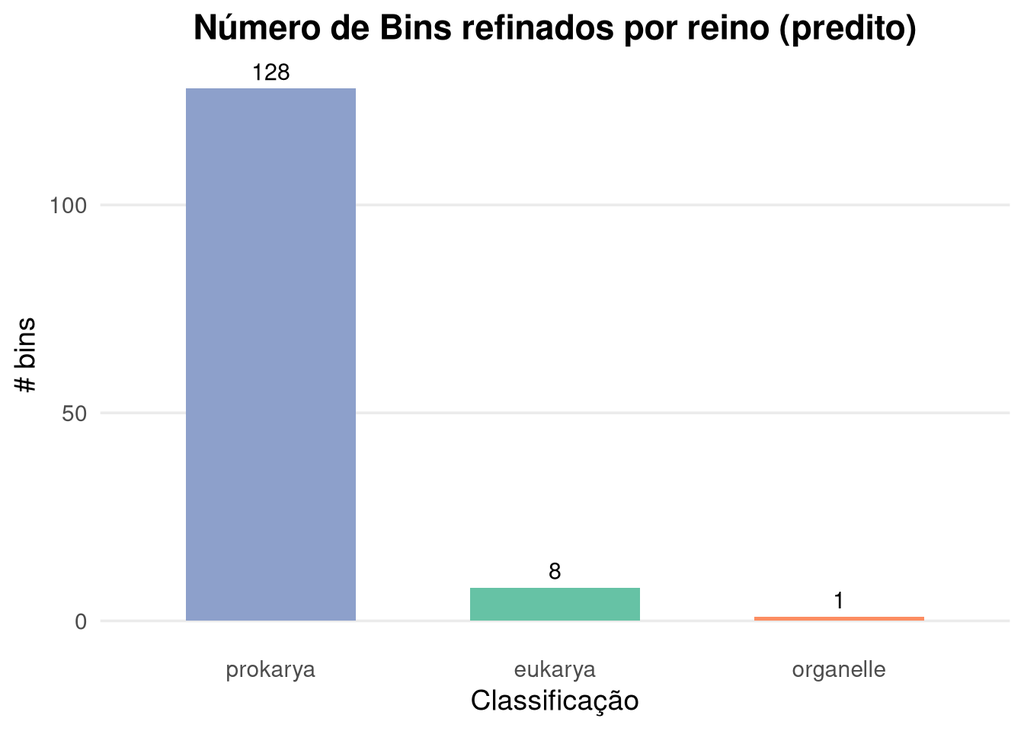

## Classificação taxonômica dos bins

Realizamos a classificação taxonômica dos bins para **táxons de Bacteria e Archaea** de acordo com a referência GTDB-Tk (Chaumeil et al. 2022).

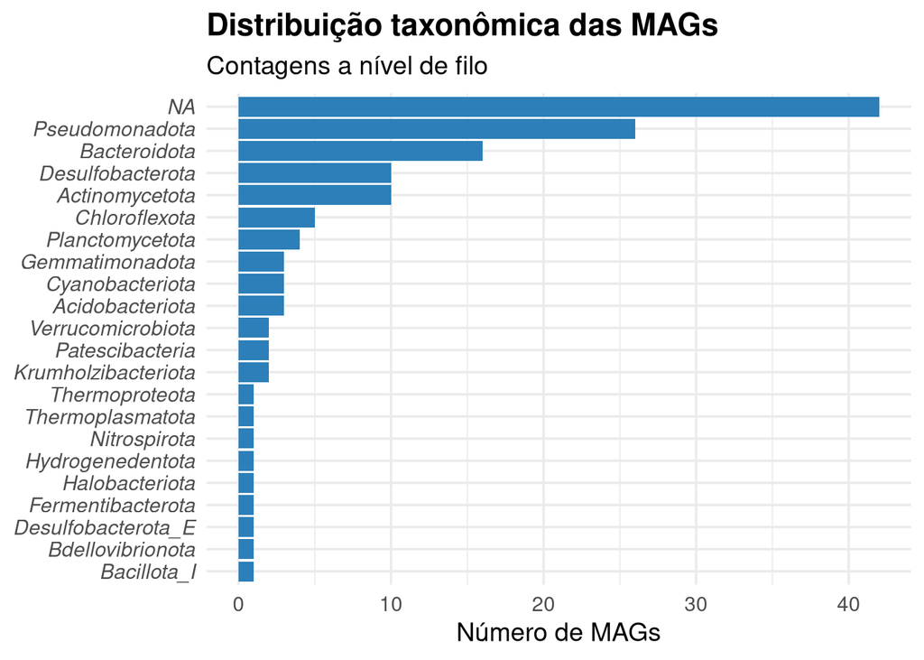

Distribuição dos principais filos identificados a partir de genomas montados de metagenomas (MAGs). O gráfico de barras exibe o número total de MAGs classificados em diferentes filos com base no Genome Taxonomy Database (GTDB). A análise revela que *Pseudomonadota* e *Bacteroidota* são os filos mais representados no conjunto de dados. Mais de 40 MAGs não puderam ser classificadas, 8 pertencendo a Eukarya de acordo com o Tiara.

# Passos futuros

- Classificação das MAGs eucarióticas.
- Anotação funcional das montagens
  - Busca de clusters gênicos biosintéticos
  - Identificação de genes de resistência a antibióticos
  - Identificação de peptídeos antimicrobianos

## Referências

Alneberg, Johannes, Brynjar Smari Bjarnason, Ino de Bruijn, Melanie Schirmer, Joshua Quick, Umer Z. Ijaz, Leo Lahti, Nicholas J. Loman, Anders F. Andersson, e Christopher Quince. 2014. «Binning metagenomic contigs by coverage and composition». *Nature Methods* 11 (11): 1144–46. https://doi.org/10.1038/nmeth.3103.

Andrews, Simon. 2010. «FastQC: A Quality Control tool for High Throughput Sequence Data». http://www.bioinformatics.babraham.ac.uk/projects/fastqc/.

Chaumeil, Pierre-Alain, Aaron J Mussig, Philip Hugenholtz, e Donovan H Parks. 2022. «GTDB-Tk v2: memory friendly classification with the genome taxonomy database». *Bioinformatics* 38 (23): 5315–16. https://doi.org/10.1093/bioinformatics/btac672.

Chen, Shifu, Yanqing Zhou, Yaru Chen, e Jia Gu. 2018. «fastp: an ultra-fast all-in-one FASTQ preprocessor». *Bioinformatics* 34 (17): i884–90. https://doi.org/10.1093/bioinformatics/bty560.

Kang, Donovan D., Jeff Froula, Rob Egan, e Zhong Wang. 2019. «MetaBAT 2: an adaptive binning algorithm for robust and efficient genome reconstruction from metagenome assemblies». *PeerJ* 7: e7359. https://doi.org/10.7717/peerj.7359.

Karlicki, Michał, Stanisław Antonowicz, e Anna Karnkowska. 2021. «Tiara: deep learning-based classification system for eukaryotic sequences». *Bioinformatics* 38 (2): 344–50. https://doi.org/10.1093/bioinformatics/btab672.

Krakau, Sabrina, Daniel Straub, Hadrien Gourlé, Gisela Gabernet, e Sven Nahnsen. 2022. «nf-core/mag: a best-practice pipeline for metagenome hybrid assembly and binning». *NAR Genomics and Bioinformatics* 4 (1): lqac007. https://doi.org/10.1093/nargab/lqac007.

Li, Dinghua, Chi-Man Liu, Ruibang Luo, Kunihiko Sadakane, e Tak-Wah Lam. 2015. «MEGAHIT: an ultra-fast single-node solution for large and complex metagenomics assembly via succinct de Bruijn graph». *Bioinformatics* 31 (10): 1674–76. https://doi.org/10.1093/bioinformatics/btv033.

Sieber, Christian M. K., Alexander J. Probst, Allison Sharrar, Brian C. Thomas, Matthias Hess, Susannah G. Tringe, e Jillian F. Banfield. 2018. «Recovery of genomes from metagenomes via a dereplication, aggregation and scoring strategy». *Nature Microbiology* 3 (7): 836–43. https://doi.org/10.1038/s41564-018-0171-1.

Wood, Derrick E., Jennifer Lu, e Ben Langmead. 2019. «Improved metagenomic analysis with Kraken 2». *Genome Biology* 20 (1): 257. https://doi.org/10.1186/s13059-019-1891-0.

Wu, Yu-Wei, Blake A. Simmons, e Steven W. Singer. 2016. «MaxBin 2.0: an automated binning algorithm to recover genomes from multiple metagenomic datasets». *Bioinformatics* 32 (4): 605–7. https://doi.org/10.1093/bioinformatics/btv638.